# How Does a Bike-Share Navigate Speedy Success?

```r
library(tidyverse)
library(skimr)
library(lubridate)
library(janitor)
library(readr)
library(gt)
library(scales)
```

## 1. Describing Scenario

### 1.1 Background

You are a junior data analyst working in the marketing analyst team at Cyclistic, a bike-share company in Chicago. The director of marketing believes the company’s future success depends on maximizing the number of annual memberships. Therefore, your team wants to understand how casual riders and annual members use Cyclistic bikes differently. From these insights, your team will design a new marketing strategy to convert casual riders into annual members. But first, Cyclistic executives must approve your recommendations, so they must be backed up with compelling data insights and professional data visualizations.

Cyclistic’s marketing strategy relied on building general awareness and appealing to broad consumer segments. One approach that helped make these things possible was the flexibility of its pricing plans: single-ride passes, full-day passes, and annual memberships. Customers who purchase single-ride or full-day passes are referred to as casual riders. Customers who purchase annual memberships are Cyclistic members.

Cyclistic’s finance analysts have concluded that annual members are much more profitable than casual ridersAlthough the pricing flexibility helps Cyclistic attract more customers, your manager believes that maximizing the number of annual members will be key to future growth.

### 1.2 Business Task

Analyze the historical bike data of Cyclistic to identify trends and derive insights to help marketing team with new marketing strategy.

### 1.3 Objectives

- How do annual members and casual riders use Cyclistic bikes differently?
- Why would casual riders buy Cyclistic annual memberships?
- How can Cyclistic use digital media to influence casual riders to become members?

### 1.4 Stakeholders

- **Lily Moreno:** The director of marketing and your manager.
- **Cyclistic marketing analytics team:** A team of data analysts who are responsible for collecting, analyzing, and reporting data.
- **Cyclistic executive team:** The notoriously detail-oriented executive team will decide whether to approve the recommended marketing program.

## 2. Preparation of Data

### 2.1 Information about dataset

From January 2021 to December 2021, a total of 12 datasets have been made accessible for each month. Each dataset contains the specifics of every ride registered by clients of Cyclistic . This data has been cleaned to remove rider’s personal information before being made public.

We have 13 columns and we can infer their content:

- **ride_id**: Id for each trip taken, as of now we are not sure if they are unique or not, we have to find out
- **rideable_type**: Represents the type of a bike
- **started_at**: Date and time of the start time
- **ended_at**: Date and time of the end time
- **start_station_name**: Name of the starting station
- **start_station_id**: Id of the starting station
- **end_station_name**: Name of the ending station
- **end_station_id**: Id of the ending station
- **start_lat**: Latitude of the starting point
- **start_lng**: Longitude of the starting point
- **end_lat**: Latitude of the ending point
- **end_lng**: Longitude of the ending point
- **member_casual**: Represents the membership status

```r
ds1 <- read.csv("202101-divvy-tripdata.csv")
ds2 <- read.csv("202102-divvy-tripdata.csv")
ds3 <- read.csv("202103-divvy-tripdata.csv")
ds4 <- read.csv("202104-divvy-tripdata.csv")
ds5 <- read.csv("202105-divvy-tripdata.csv")
ds6 <- read.csv("202106-divvy-tripdata.csv")
ds7 <- read.csv("202107-divvy-tripdata.csv")
ds8 <- read.csv("202108-divvy-tripdata.csv")
ds9 <- read.csv("202109-divvy-tripdata.csv")
ds10 <- read.csv("202110-divvy-tripdata.csv")
ds11 <- read.csv("202111-divvy-tripdata.csv")
ds12 <- read.csv("202112-divvy-tripdata.csv")
```

Merge all data frames into one big data frame

```r
df <- rbind(ds1,ds2,ds3,ds4,ds5,ds6,ds7,ds8,ds9,ds10,ds11,ds12)
```

## 3. Processing of Data

### 3.1 Manipulating Data

- Changing data type of `started_at` and `ended_at` from Character to Datetime

```r
df$started_at <- ymd_hms(df$started_at)
df$ended_at <- ymd_hms(df$ended_at)
```

- Adding some relevant columns like `ride_length`, `day_of_week`, `Month`, `Day` to data for smoothing the analysis process.

```r
df1 <- df %>%
  mutate(ride_length = difftime(ended_at,started_at,units = "mins")) %>%
  mutate(day_of_week = weekdays(as.Date(df$started_at))) %>%
  mutate(Month = month(df$started_at,label = TRUE)) %>%
  mutate(Day = day(df$started_at))
```

- Checking if there is any `ride_length` value is negative.

```r
df1 %>%
  count(ride_length<0) %>%
  gt()
```

| ride_length < 0 | n |
| --- | --- |
| FALSE | 5594916 |
| TRUE | 147 |

Yes, there are some rows with negative `ride_length` and because of that we have to remove these rows as it can be a hindrance in the analysis process.

```r
df1 <- df1[!(df1$ride_length< 0),]
```

- Converting `ride_length` from Factor to numeric so we can run calculations on the data.

```r
df1$ride_length <- as.numeric(as.character(df1$ride_length))
```

### 3.2 Summary Statistics of Dataset

```r
skim_without_charts(df1)
```

Data summary

| Name | df1 |
| --- | --- |
| Number of rows | 5594916 |
| Number of columns | 17 |
| _______________________ |  |
| Column type frequency: |  |
| character | 8 |
| factor | 1 |
| numeric | 6 |
| POSIXct | 2 |
| ________________________ |  |
| Group variables | None |

**Variable type: character**

| skim_variable | n_missing | complete_rate | min | max | empty | n_unique | whitespace |
| --- | --- | --- | --- | --- | --- | --- | --- |
| ride_id | 0 | 1.00 | 16 | 16 | 0 | 5594916 | 0 |
| rideable_type | 0 | 1.00 | 11 | 13 | 0 | 3 | 0 |
| start_station_name | 690789 | 0.88 | 3 | 53 | 0 | 847 | 0 |
| start_station_id | 690786 | 0.88 | 3 | 36 | 0 | 834 | 0 |
| end_station_name | 739149 | 0.87 | 10 | 53 | 0 | 844 | 0 |
| end_station_id | 739149 | 0.87 | 3 | 36 | 0 | 832 | 0 |
| member_casual | 0 | 1.00 | 6 | 6 | 0 | 2 | 0 |
| day_of_week | 0 | 1.00 | 6 | 9 | 0 | 7 | 0 |

**Variable type: factor**

| skim_variable | n_missing | complete_rate | ordered | n_unique | top_counts |
| --- | --- | --- | --- | --- | --- |
| Month | 0 | 1 | TRUE | 12 | Jul: 822397, Aug: 804323, Sep: 756111, Jun: 729590 |

**Variable type: numeric**

| skim_variable | n_missing | complete_rate | mean | sd | p0 | p25 | p50 | p75 | p100 |
| --- | --- | --- | --- | --- | --- | --- | --- | --- | --- |
| start_lat | 0 | 1 | 41.90 | 0.05 | 41.64 | 41.88 | 41.90 | 41.93 | 42.07 |
| start_lng | 0 | 1 | -87.65 | 0.03 | -87.84 | -87.66 | -87.64 | -87.63 | -87.52 |
| end_lat | 4770 | 1 | 41.90 | 0.05 | 41.39 | 41.88 | 41.90 | 41.93 | 42.17 |
| end_lng | 4770 | 1 | -87.65 | 0.03 | -88.97 | -87.66 | -87.64 | -87.63 | -87.49 |
| ride_length | 0 | 1 | 21.94 | 178.34 | 0.00 | 6.75 | 12.00 | 21.78 | 55944.15 |
| Day | 0 | 1 | 15.45 | 8.79 | 1.00 | 8.00 | 15.00 | 23.00 | 31.00 |

**Variable type: POSIXct**

| skim_variable | n_missing | complete_rate | min | max | median | n_unique |
| --- | --- | --- | --- | --- | --- | --- |
| started_at | 0 | 1 | 2021-01-01 00:02:05 | 2021-12-31 23:59:48 | 2021-08-01 01:48:51 | 4677893 |
| ended_at | 0 | 1 | 2021-01-01 00:08:39 | 2022-01-03 17:32:18 | 2021-08-01 02:18:49 | 4671279 |

We can see right immediately that there is an outlier data under `ride_length`, with a maximum trip time of **55944** minutes, or about **38 days**. This might be due to a data error or the fact that the individual rented it for 38 days.

### 3.3 Glipmse of Dataset

```r
gt(head(df1))
```

| ride_id | rideable_type | started_at | ended_at | start_station_name | start_station_id | end_station_name | end_station_id | start_lat | start_lng | end_lat | end_lng | member_casual | ride_length | day_of_week | Month | Day |
| --- | --- | --- | --- | --- | --- | --- | --- | --- | --- | --- | --- | --- | --- | --- | --- | --- |
| E19E6F1B8D4C42ED | electric_bike | 2021-01-23 16:14:19 | 2021-01-23 16:24:44 | California Ave & Cortez St | 17660 | NA | NA | 41.90034 | -87.69674 | 41.89 | -87.72 | member | 10.4166667 | Saturday | Jan | 23 |
| DC88F20C2C55F27F | electric_bike | 2021-01-27 18:43:08 | 2021-01-27 18:47:12 | California Ave & Cortez St | 17660 | NA | NA | 41.90033 | -87.69671 | 41.90 | -87.69 | member | 4.0666667 | Wednesday | Jan | 27 |
| EC45C94683FE3F27 | electric_bike | 2021-01-21 22:35:54 | 2021-01-21 22:37:14 | California Ave & Cortez St | 17660 | NA | NA | 41.90031 | -87.69664 | 41.90 | -87.70 | member | 1.3333333 | Thursday | Jan | 21 |
| 4FA453A75AE377DB | electric_bike | 2021-01-07 13:31:13 | 2021-01-07 13:42:55 | California Ave & Cortez St | 17660 | NA | NA | 41.90040 | -87.69666 | 41.92 | -87.69 | member | 11.7000000 | Thursday | Jan | 7 |
| BE5E8EB4E7263A0B | electric_bike | 2021-01-23 02:24:02 | 2021-01-23 02:24:45 | California Ave & Cortez St | 17660 | NA | NA | 41.90033 | -87.69670 | 41.90 | -87.70 | casual | 0.7166667 | Saturday | Jan | 23 |
| 5D8969F88C773979 | electric_bike | 2021-01-09 14:24:07 | 2021-01-09 15:17:54 | California Ave & Cortez St | 17660 | NA | NA | 41.90041 | -87.69676 | 41.94 | -87.71 | casual | 53.7833333 | Saturday | Jan | 9 |

## 4. Anlaysis Phase

### 4.1 Descriptive Analysis

```r
analysis1 <- df1 %>%
  group_by(member_casual,day_of_week) %>%
  summarise(Mean_ride_length = mean(ride_length), Median_ride_length = median(ride_length) ,Max_ride_length = max(ride_length),Min_ride_length = min(ride_length), count = n())%>%
  gt()
analysis1 <- data.frame(analysis1)
analysis1 %>%
  group_by(member_casual) %>%
  gt()
```

| day_of_week | Mean_ride_length | Median_ride_length | Max_ride_length | Min_ride_length | count |
| --- | --- | --- | --- | --- | --- |
| casual |  |  |  |  |  |
| Monday | 31.87545 | 15.950000 | 31681.650 | 0 | 286373 |
| Tuesday | 27.97233 | 14.283333 | 38922.917 | 0 | 274388 |
| Wednesday | 27.65731 | 13.966667 | 38963.083 | 0 | 278948 |
| Thursday | 27.70326 | 13.783333 | 49107.150 | 0 | 286064 |
| Friday | 30.34860 | 14.966667 | 55691.683 | 0 | 364075 |
| Saturday | 34.70623 | 17.816667 | 55944.150 | 0 | 557994 |
| Sunday | 37.56658 | 18.716667 | 53921.600 | 0 | 481104 |
| member |  |  |  |  |  |
| Monday | 13.24753 | 9.200000 | 1499.950 | 0 | 416204 |
| Tuesday | 12.78812 | 9.133333 | 1499.950 | 0 | 465509 |
| Wednesday | 12.81916 | 9.216667 | 1499.967 | 0 | 477156 |
| Thursday | 12.77618 | 9.133333 | 1499.950 | 0 | 451520 |
| Friday | 13.32492 | 9.433333 | 1499.950 | 0 | 446423 |
| Saturday | 15.26457 | 10.816667 | 1559.933 | 0 | 433041 |
| Sunday | 15.65794 | 10.866667 | 1499.933 | 0 | 376117 |

### 4.2 Graphical Analysis

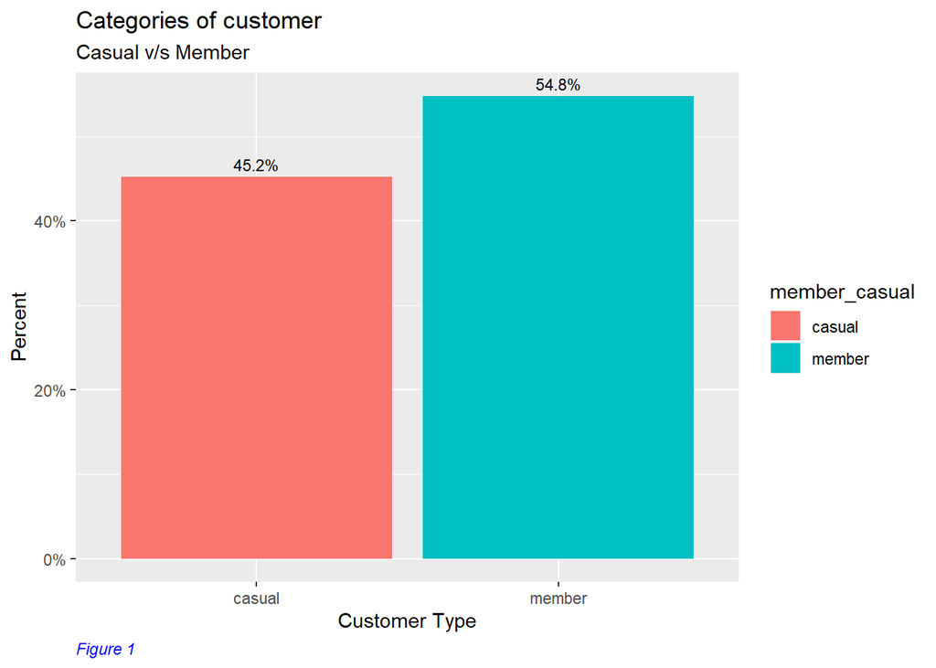

```r
ggplot(data=df1,aes(x=member_casual,y = prop.table(stat(count)),fill = member_casual,label = scales::percent(prop.table(stat(count)))))+
  geom_bar(position = "dodge") +
  geom_text(stat = 'count',position = position_dodge(.9),vjust = -0.5,size = 3) +
  scale_y_continuous(labels = scales::percent)+
  labs(title = "Categories of customer",subtitle = "Casual v/s Member",x="Customer Type",y="Percent",caption = "Figure 1")+
  theme(
  plot.caption = element_text(color = "blue", face = "italic",hjust = 0)
)
```

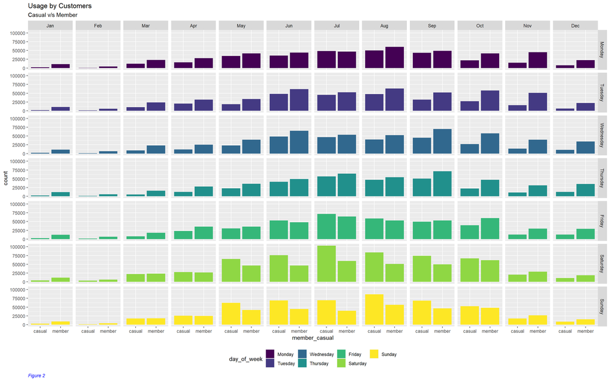

```r
ggplot(data = df1)+
  geom_bar(mapping = aes(x=member_casual,fill = day_of_week))+
  facet_grid(day_of_week~Month)+
  theme(legend.position = "bottom")+
  labs(title = "Usage by Customers",subtitle = "Casual v/s Member",caption = "Figure 2")+
  theme(
  plot.caption = element_text(color = "blue", face = "italic",hjust = 0)
)
```

```r
analysis3 <- df1 %>%
  group_by(Month,member_casual) %>%
  summarise(Number_of_Riders = n(), Average_Ride_Time = mean(ride_length))
```

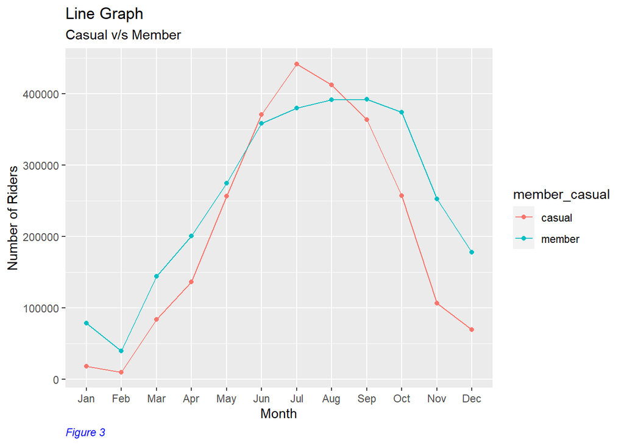

```r
analysis3 %>%
ggplot(aes(x = Month, y=Number_of_Riders,group = member_casual,colour = member_casual)) +
  geom_point() +
  geom_line() +
  labs(title = "Line Graph",subtitle = "Casual v/s Member",y="Number of Riders",caption = "Figure 3")+
  theme(
  plot.caption = element_text(color = "blue", face = "italic",hjust = 0)
)
```

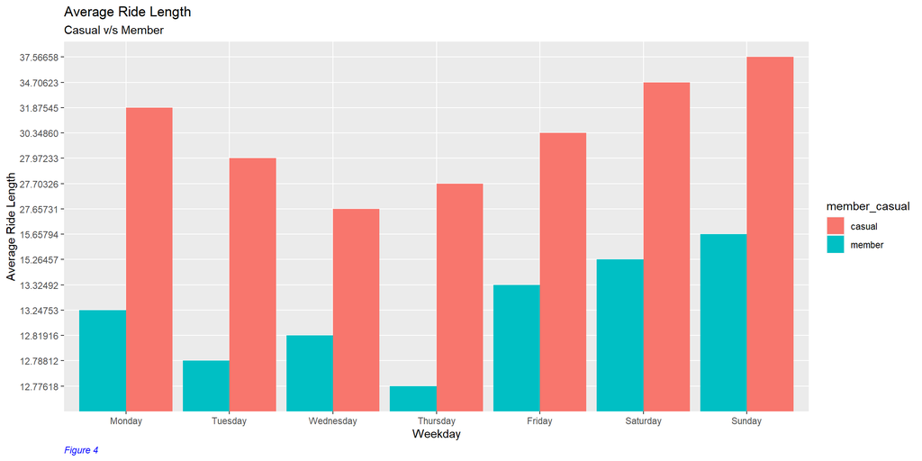

```r
ggplot(data = analysis1,aes(x = day_of_week, y = Mean_ride_length, fill = member_casual)) +
  geom_col(position = "dodge") +
  labs(title = "Average Ride Length",subtitle = "Casual v/s Member",x="Weekday",y="Average Ride Length",caption = "Figure 4")+
  theme(
  plot.caption = element_text(color = "blue", face = "italic",hjust = 0)
)
```

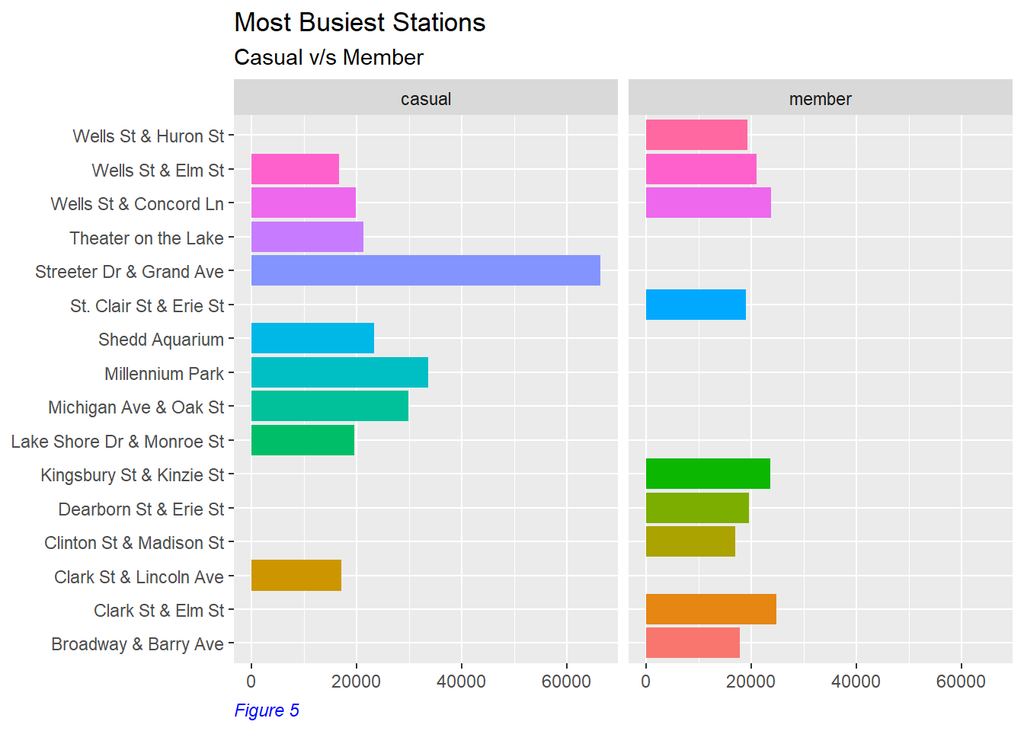

```r
Top10 <- df1 %>%
  group_by(member_casual) %>%
  count(start_station_name,sort = TRUE) %>%
  slice(1:10)
Top10 <- data.frame(Top10)
Top10 %>%
  filter(!start_station_name == "") %>%
  ggplot(aes(x=n,y=start_station_name,fill = start_station_name))+
  geom_bar(stat='identity')+
  facet_wrap(~member_casual)+
  theme(legend.position = "none",axis.title.x = element_blank(),axis.title.y = element_blank())+
  labs(title = "Most Busiest Stations",subtitle = "Casual v/s Member",caption = "Figure 5")+
  theme(
  plot.caption = element_text(color = "blue", face = "italic",hjust = 0)
  )
```

## 5. Conclusion

### 5.2 Suggetions

- We can conduct **marketing campaigns** on those most popular stations and at the **weekends** because then it can target a **larger audience.**
- We can design annual membership in a way that seems much **more reliable than daily passes**. In doing so we have to add some more **perks**, some **gift**s or something like that if you purchase our annual membership with a certain credit card, you can get **some additional instant discount.**
- We can **increase the price of a daily pass on weekends** only because there are much more rides taken on weekends by casual users and casual users may find it feasible to purchase an annual membership rather than a daily pass.